# R for Humans, Ensemble Modeling, and Deep learning

February 15th, 2018

## Tonights talks

A potpourri of talks, spanning a range of R topics!

*Best practices in writing readable & maintainable R code* - [Peter Hurford](https://github.com/iveksl2)

*Ensemble modeling, sports analytics & hedge funds* - [Igor Veksler](https://github.com/iveksl2)

*Deep Learning with R using Keras* - [Rajiv Shah](http://RajivShah.com)

Special Thanks to IBM for sponsoring this meetup and making it possible!

## Intro to tonight's talks

## 1880: Statistician solves a Big Data problem

**1880** Since its inception in 1790, the U.S. census has expanded dramatically. It takes 8 years to process.

Herman Hollerith, *a Statistician of the 1880 census*, sets out to process it faster. Inspired by railway conductors, he creates punch cards to collect data. Inserted into a machine, the holes in each card allow an electrical circuit to complete, advancing a counting wheel for each topic and card.

**1890** The first census to use Hollerith's Tabulating Machine is a success, completing in just 1 year.

**1896** Hollerith forms the "Tabulating Machine Company", which merges with others to become **International Business Machines**, or **IBM**.

Sources: [Census.gov/history](https://www.census.gov/history/www/census_then_now/notable_alumni/herman_hollerith.html) and pg. 36 *The Innovators*, Walter Isaacson

[figure not shown]

## John Tukey, a Data Science pioneer

**1962** [*The Future of Data Analysis*](https://www.jstor.org/stable/2237638)

*For a long time I have thought I was a statistician, interested in inferences from the particular to the general. … I have come to feel that my central interest is in data analysis, which I take to include, among other things: procedures for analyzing data, techniques for interpreting the results of such procedures, ways of planning the gathering of data to make its analysis easier, more precise or more accurate, and all the machinery and results of (mathematical) statistics which apply to analyzing data.*

**1964** [*The technical tools of statistics*](http://ect.bell-labs.com/sl/tukey/memo/techtools.html)

*Today, software and hardware together provide far more powerful factories than most statisticians realize, factories that many of today's most able young people find exciting and worth learning about on their own.*

**1977**: [Exploratory Data Analysis](https://www.amazon.com/Exploratory-Data-Analysis-John-Tukey/dp/0201076160)

*Since the aim of exploratory data analysis is to learn what seems to be, it should be no surprise that pictures play a vital role in doing it well. There is nothing better for making you think of questions you had forgotten to ask (even mentally)*

Tukey's championing of EDA encouraged the development of statistical computing packages, especially S at Bell Labs. The S programming language inspired the systems 'S'-PLUS and **`R`**. This family of statistical-computing environments featured vastly improved dynamic visualization capabilities, which allowed statisticians to identify outliers, trends and patterns in data that merited further study.

[Source: Wiki Exploratory Data Analysis](https://en.wikipedia.org/wiki/Exploratory_data_analysis)

## R (and S) for Humans, always the goal!

They wanted a more interactive process, where they could just type an expression at the command line and get back an immediate response, or better yet, a bar graph or other visual.

**1977: *Analalysis that was once difficult became easy in S*.**

**1991** `R`, based entirely on `S`, is created by Ross Ihaka and Robert Gentleman, borrowing all the hard-won lessons developed by the S community.

[Source: From S to R: 35 Years of Leadership in Statistical Computing](http://www.research.att.com/articles/featured_stories/2013_09/201309_SandR.html)

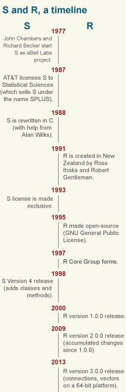

## A rich history of extending R, prior to Keras

R succeeds today because it is very easy to extend.

If the driving force behind S was interactivity, for R it was extensibility. Partly this extensibility stems from S, which was designed to interface easily with outside elements (specifically with subroutine libraries). R retains this interfacing capability so it easily incorporates native code as well as objects, analysis, and visualizations created in other programs, giving R users options outside of R. And R is extensible also because it's open source.

Objects created in other systems and then imported into R are accessed in the same way R objects are accessed. It's easy to write native code in Java, C++, or any other language, and then have R call the code directly, with almost no loss in speed or performance.

[Source: From S to R: 35 Years of Leadership in Statistical Computing](http://www.research.att.com/articles/featured_stories/2013_09/201309_SandR.html)

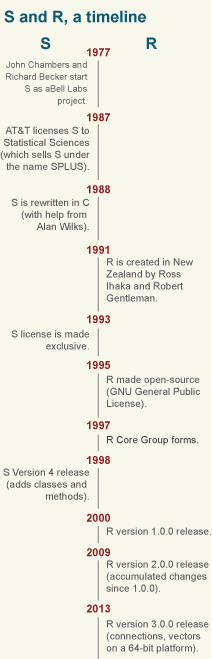

## Ensemble Methods, some early history

**1984** Classification and Regression Trees, Leo Breiman and Jerome H. Friedman

**1994** Bagging Predictors, Leo Breiman

**1995** Random Decision Forests, Tin Kam Ho at **Bell Labs**

**1999** Random Forest - *Random Features*, Leo Breiman

**2000 AdaBoost** Additive Logistic Regression: A Statistical View of Boosting. Jerome Friedman, Trevor Hastie, Rob Tibshirani.

**2001 *The Two Cultures***. Leo Breiman.

**2002** `randomForest` package. Breiman & Cutler's Fortran Code ported to R by Andy Liaw and Matthew Wiener.

[Source Revolution Analytics blog: A Thumbnail History of Ensemble Methods](http://blog.revolutionanalytics.com/2014/03/a-thumbnail-history-of-ensemble-methods.html)

[figure not shown]